# Monte Carlo Methods: Sampling Algorithms

Calum Smith 2026-01-25

```r
rm(list=ls())
library(ggplot2)
library(dplyr)

set.seed(20)
```

# 1. Inverse Transform Sampling

Let $Y = X^\alpha$ where $\alpha = 2k+1$ for $k \in \mathbb{N} \cup \{0\}$.The cumulative distribution function (CDF) of $Y$, $F_Y(y)$, is given by:

$$\begin{aligned}
F_Y(y) &= \mathbb{P}(Y \le y) \\
&= \mathbb{P}(X^\alpha \le y) \\
&= \mathbb{P}(X \le y^{1/\alpha}) \\
&= F_X(y^{1/\alpha})
\end{aligned}$$

Since $\alpha$ is odd, the function $g(x) = x^\alpha$ is strictly increasing and invertible. The CDF of a Laplace random variable with $\mu=0$ and $b=1$ if given by

$$F_X(x) =
\begin{cases}
\frac{1}{2} e^x & \text{if } x < 0 \\
1 - \frac{1}{2} e^{-x} & \text{if } x \geq 0
\end{cases}$$

From the above we evaluate the Laplace CDF at $x=y^{1/\alpha}$ to give the CDF of Y,

$$F_Y(y) =
\begin{cases}
\frac{1}{2} e^{y^{1/\alpha}} & \text{if } y < 0 \\
1 - \frac{1}{2} e^{-y^{1/\alpha}} & \text{if } y \ge 0
\end{cases}$$

To obtain the probability density function of $Y$ we use the Fundamental Theorem of Calculus which gives the identity

$$\begin{aligned}
f_Y(y) &= \frac{d}{dy}F_Y(y) \\
&= \begin{cases}
\frac{1}{2\alpha} y^{\frac{1}{\alpha} - 1}
e^{y^{\frac{1}{\alpha}}} & \text{if } y<0 \\
\frac{1}{2\alpha} y^{\frac{1}{\alpha}-1}
e^{-y^{\frac{1}{\alpha}}} & \text{if } y\geq 0
\end{cases}
\end{aligned}$$

We can simplify the PDF of $Y$ by considering the cases for $y$ and combining them.(i) when $y<0$ we have $f_Y(y) = \frac{1}{2\alpha} y^{\frac{1}{\alpha}-1} e^{y^{\frac{1}{\alpha}}}$. Since $y$ is negative, $y^{1/\alpha}$ is also negative for odd $\alpha$ so $|y^{1/\alpha}| = -y^{1/\alpha}$. Hence, $e^{-{|y^{1/\alpha}|}}$ when $y>0$ we have $f_Y(y) = \frac{1}{2\alpha} y^{\frac{1}{\alpha}-1} e^{-y^{\frac{1}{\alpha}}}$. Since $y$ is positive, we know that $y^{1/\alpha}$ for odd $\alpha$ and so $|y^{1/\alpha}| = y^{1/\alpha}$. Hence, $e^{-{|y^{1/\alpha}|}}$. Combining the above gives,

$$f_Y(y) = \frac{1}{2\alpha}
y^{\frac{1}{\alpha} - 1} e^{-{|y^{\frac{1}{\alpha}}|}} \quad \text{for }
-\infty < y < \infty$$

To sample from the distribution of $Y$, we can use the inverse transform sampling method. Here the CDF of $Y$ is given as

$$\begin{aligned}
F_Y(y) =
\begin{cases}
\frac{1}{2} e^{y^{1/\alpha}} & \text{if } y < 0 \\
1 - \frac{1}{2} e^{-y^{1/\alpha}} & \text{if } y \ge 0
\end{cases}
\end{aligned}$$

First, we need to generate a uniform random variable $U \sim U(0,1)$. Then, we set $F_Y(y) = u$ and solve for $y$. This involves finding the inverse of the CDF of Y and evaluating it at $u$ for each case. Setting $u=F_Y(y)$ and rearranging gives

$$F_Y^{-1}(u) =
\begin{cases}
[\ln(2u)]^\alpha & \text{if } 0 < u \le \frac{1}{2} \\
[-\ln(2(1-u))]^\alpha & \text{if } \frac{1}{2} < u < 1
\end{cases}$$
where the ranges of $u$ are found by looking at how the the CDF changes for $y \in (-\infty, 0)$ and $y\in (0, \infty)$.

## Implementation

The following code implements this inverse CDF method for various values of $\alpha$.

```r
# Define the Sampling Function
gicdf.y <- function(u, alpha) {
  x <- numeric(length(u))
  ind.neg <- (u <= 0.5)
  x[ind.neg] <- log(2 * u[ind.neg])
  x[!ind.neg] <- -log(2 * (1 - u[!ind.neg]))
  y <- sign(x) * (abs(x))^alpha
  return(y)
}

# Generate the Sample Data
n.samples <- 1000
alphas <- c(1, 3, 5)

samples <- lapply(alphas, function(a) {
  u.values <- runif(n.samples)
  alpha.vec <- rep(a, n.samples)
  gicdf.y(u.values, alpha.vec)
})
```

### Plot of the target distributions

To verify the distribution, we can plot a histogram of the generated samples and overlay the theoretical probability density function (PDF) derived in part (a).

For $\alpha = 1$, the density of $Y$ is the Laplace distribution as described above so we get the characteristic tent shape centred at 0. As we increase the value of $\alpha$, the density of $Y$ gets stretched and the tails become very heavy. This makes sense because for example, if $X=3$ then under the transformation with $\alpha=3$ we have that $Y=3^3=27$ and so we are spreading out the density for values of $X$. Moreover, the values close to 0 get even closer due to $\alpha$ which causes the spike as $\alpha$ increases.

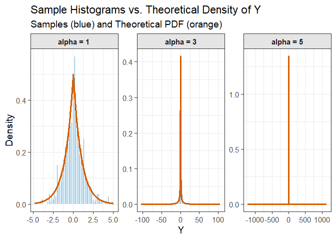

```r
# Define the theoretical PDF of Y
d_Y <- function(y, alpha) {
  term1 <- 1 / (2 * alpha)
  term2 <- abs(y)^((1 - alpha) / alpha)
  term3 <- exp(-abs(y)^(1 / alpha))


  density <- term1 * term2 * term3
  density[y == 0 & alpha > 1] <- 0
  density[y == 0 & alpha == 1] <- 0.5

  return(density)
}

plot_data <- mapply(function(s, a) data.frame(y = s, alpha = a),
                    samples, alphas, SIMPLIFY = FALSE) %>%
  bind_rows() %>%
  mutate(alpha_label = factor(paste("alpha =", alpha)))

# Trim the data for better visualisation
trimmed_plot_data <- plot_data %>%
  group_by(alpha_label) %>%
  mutate(q_low = quantile(y, 0.005),
         q_high = quantile(y, 0.995)) %>%
  filter(y >= q_low & y <= q_high) %>%
  ungroup()

# Create the theoretical density data for the lines
theory_data <- trimmed_plot_data %>%
  group_by(alpha_label, alpha) %>%
  summarise(min_y = min(y), max_y = max(y)) %>%
  group_by(alpha_label, alpha) %>%
  summarise(y = seq(min_y, max_y, length.out = 501)) %>%
  mutate(pdf = d_Y(y, alpha)) %>%
  ungroup()

# Generate the plot
ggplot(trimmed_plot_data, aes(x = y)) +

  # Histogram of the samples
  geom_histogram(aes(y = after_stat(density)),
                 bins = 100,
                 fill = "#0072B2",
                 alpha = 0.6,
                 color = "white",
                 linewidth = 0.2) +

  # Theoretical density line
  geom_line(data = theory_data,
            aes(x = y, y = pdf),
            color = "#D55E00",
            linewidth = 1.2) +

  facet_wrap(~ alpha_label, scales = "free") +

  labs(
    title = "Sample Histograms vs. Theoretical Density of Y",
    subtitle = "Samples (blue) and Theoretical PDF (orange)",
    x = "Y",
    y = "Density"
  ) +
  theme_bw(base_size = 14) +
  theme(
    strip.background = element_rect(fill = "grey90"),
    strip.text = element_text(face = "bold")
  )
```

# 2. Optimization of Rejection Sampling

For a distribution with PDF $q(x)$ to be a valid proposal distribution for the target distribution with PDF $p(x)$, there must exist a finite constant $M$ such that the ratio $p(x)/q(x)$ is bounded for all $x$:
$$\frac{p(x)}{q(x)} \le M \quad \text{for all } x
\in (-\infty,\infty)$$
Where our target is $p(x) = \frac{1}{2\alpha}x^{\frac{1}{\alpha}-1} e^{-{|x^{\frac{1}{\alpha}}|}}$ and the proposal $q(x)$ is the $t$-distribution given in the question. In order to analyse the behaviour of the densities we need to write them both with respect to $x$. To determine the value of $\alpha$ we need to examine the behaviour of ratio of the densities at:$x \to 0$ since this is the value at which we get the mode for both densities$x \to \infty$ to check how the tails behaveChecking each limit in turn we get:
$$\lim_{x \to 0} \frac{p(x)}{q(x)} =
\lim_{x \to 0} \frac{\frac{1}{2\alpha}x^{\frac{1}{\alpha}-1}
e^{-{|x^{\frac{1}{\alpha}}|}}}{q(x)}$$
We know that the $t$-distribution with $\nu$ degrees of freedom has a finite constant mode for any $\nu \in (0, \infty)$ so we can write $\lim_{x\to 0}q(x)=C$ for some $C>0$. Now, we have that the limit reduces to
$$\lim_{x \to 0} \frac{p(x)}{q(x)} =
\frac{1}{2\alpha C} \lim_{x\to 0} x^{\frac{1}{\alpha} - 1}$$
So the limit of the ratio depends on the sign of $\frac{1}{\alpha} - 1$. Now we consider two cases:$\alpha=1$: In this case the limit reduces to $1/2C$ which is a finite positive constant. For the case when $x \to \infty$, the ratio goes to 0 because the exponential tail of $p(x)$ decays faster that the polynomial tail of $q(x)$. Since the ratio is a continuous function that is finite at $x=0$ and tends to 0 at infinity, it is bounded over its entire domain. Hence, a $t$-distribution is a valid proposal for $\alpha=1$.$\alpha > 1$: In this case, $\frac{1}{\alpha} - 1 < 0$. This means that
$$\frac{1}{2\alpha C} \lim_{x\to 0}
x^{\frac{1}{\alpha} - 1} = \infty$$
so the ratio is unbounded. This means we cannot find a finite $M$ to satisfy the condition above for all $x$ close to 0. Hence, a $t$-distribution would not be a valid proposal for $\alpha > 1$.Hence, for rejection sampling to work we need to choose $\alpha=1$.

To maximise the efficiency of the rejection sampler we need to minimise the constant $M$ where $M = \sup_x \frac{f(x)}{g(x)}$. Since $M$ will depend on the parameter $\nu$ of our proposal $g(x)$, we are looking for the value $\nu^*$ that minimises $M(\nu)$. To find the maximum of this ratio we differentiate with respect to $x$ and set to 0. Once we do this, we find that the critical values are at $x=1$ and $x=\nu$. Hence,

$$\begin{align*}
M(\nu) = \frac{\sqrt{\nu
\pi}\Gamma(\frac{\nu}{2})}{2\Gamma(\frac{\nu + 1}{2})} \max(1,
e^{-\nu}(1+\nu)^{(\nu +1)/2}
\end{align*}$$

Then to find $\nu$ we need to numerically calculate it using R. After doing this we find that $\nu \approx 3.92$ minimises $M(\nu)$. The below figure shows the relationship between the size of $\nu$ and the rejection sampling constant $M$.

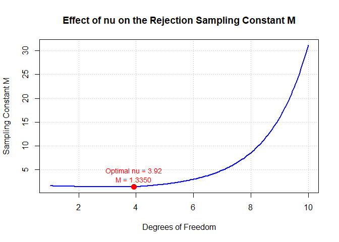

```r
# Find optimal nu
get_M <- function(nu) {
  log_C_nu <- (0.5 * log(nu * pi) +
                 lgamma(nu / 2) -
                 log(2) -
                 lgamma((nu + 1) / 2))
  C_nu <- exp(log_C_nu)
  h_at_0 <- 1.0
  log_h_at_1 <- -1.0 + ((nu + 1) / 2) * log(1 + 1/nu)
  h_at_1 <- exp(log_h_at_1)
  log_h_at_nu <- -nu + ((nu + 1) / 2) * log(1 + nu)
  h_at_nu <- exp(log_h_at_nu)
  sup_h <- max(h_at_0, h_at_1, h_at_nu)

  return(C_nu * sup_h)
}

# Find the optimal nu
opt_result <- optimize(get_M, interval = c(1, 10))
nu_optimal <- opt_result$minimum
M_optimal <- opt_result$objective

# Generate data for plotting
nu_values <- seq(1, 10, by = 0.05)
M_values <- sapply(nu_values, get_M)

# Plot
plot(nu_values, M_values,
     type = "l",
     col = "blue",
     lwd = 2,
     main = "Effect of nu on the Rejection Sampling Constant M",
     xlab = "Degrees of Freedom",
     ylab = "Sampling Constant M",
     panel.first = grid()
)

points(nu_optimal, M_optimal, col = "red", pch = 19, cex = 1.5)

text(nu_optimal, M_optimal,
     label = sprintf("Optimal nu = %.2f\nM = %.4f", nu_optimal, M_optimal),
     pos = 3,
     col = "red",
     cex = 0.9)
```

### Implemeting the rejection sampler for the optimal nu

```r
# Define varphi
phi_laplace <- function(x) {
  return(0.5 * exp(-abs(x)))
}

# Implement the Rejection Sampler

run_rejection_sampler <- function(n_samples, nu) {
  M <- get_M(nu)
  samples <- numeric(n_samples)
  n_accepted <- 0
  n_proposed <- 0
  while (n_accepted < n_samples) {
    n_proposed <- n_proposed + 1
    z <- rt(1, df = nu)
    u <- runif(1)
    g_z <- dt(z, df = nu)
    if (g_z > 0) {
      acceptance_ratio <- phi_laplace(z) / (M * g_z)
      if (u <= acceptance_ratio) {
        n_accepted <- n_accepted + 1
        samples[n_accepted] <- z
      }
    }
  }

  experimental_rate <- n_samples / n_proposed
  return(list(
    samples = samples,
    experimental_rate = experimental_rate,
    theoretical_rate = 1.0 / M,
    M = M,
    n_proposed = n_proposed,
    nu_used = nu
  ))
}

N_SAMPLES <- 10000
nu_optimal <- 3.92

# Run the sampler
res <- run_rejection_sampler(N_SAMPLES, nu_optimal)

# Compare the theoretical and experimental rates
cat(sprintf("  Target samples: %d\n", N_SAMPLES))
```

```
##   Target samples: 10000
```

```r
cat(sprintf("  Total proposals needed: %d\n", res$n_proposed))
```

```
##   Total proposals needed: 13378
```

```r
cat(sprintf("  Theoretical M: %.4f\n", res$M))
```

```
##   Theoretical M: 1.3350
```

```r
cat(sprintf("  Theoretical Rate (1/M): %.4f\n", res$theoretical_rate))
```

```
##   Theoretical Rate (1/M): 0.7491
```

```r
cat(sprintf("  Experimental Rate: %.4f\n", res$experimental_rate))
```

```
##   Experimental Rate: 0.7475
```

### Rejection Sampling vs Importance Sampling

For rejection sampling to work, we must find a finite constant $M$ as described in question 1. Let $f(x)$ be the target density and let $g(x)$ be the proposal density. We have

$$f(x) = C_1(1+\frac{t^2}{2})^{-3/2} \quad
\text{for } C_1=\frac{\Gamma(3/2)}{\sqrt{2\pi}\Gamma(1)}$$
and
$$g(x) = C_2e^{-x^2/2} \quad \text{for } C_2
= \frac{1}{\sqrt{2\pi}}$$
We can re-write the ratio as
$$\frac{C_1}{C_2}\lim_{x\to \infty}
\frac{e^{x^2/2}}{(1+\frac{x^2}{2})^{3/2}}$$
If we examine the ratio as $x \to \infty$ we can see that the numerator grows exponentially fast whereas the denominator only grows polynomially fast. This means the ratio is dominated by the numerator as $x \to \infty$ and hence, the limit is $\infty$. Since the ratio is unbounded, there is no finite $M$ and so we cannot use the standard normal as a proposal distribution in the rejection sampling method.

An importance sampling algorithm can be constructed to estimate the expectation of a function $\varphi(T)$, where $T \sim f_T(\cdot;2)$ using a proposal $g(t)$ which is the density of a $N(0,1)$ random variable. The fundamental principle of importance sampling is based on the identity:
$$\begin{align*}
\mathbb{E}_f[\varphi(T)] = \int
\varphi(t)\frac{f_T(t)}{g(t)}g(t)dt = \mathbb{E}_g[\varphi(T)w(T)]
\end{align*}$$
where the importance weights are defined as $w(T)=\frac{f_T(t)}{g(t)}$.

The proposal density of $N(0,1)$ is generally not recommended as a proposal because this will result in an estimator with infinite variance.

For an importance sampling estimate to be reliable the variance must be finite and so we want to see how the variance of the weights behaves for this proposal. We know that the weights are finite if and only if $\mathbb{E}_g(w(T)^2)$ is finite and so we want to analyse how the tail behaves as $|t|\to \infty$. For the $f_T(t;2)$ the density decays polynomially, $f_T(t;2) \propto (1+t^2/2)^{-3/2} \propto |t|^{-3}$. For the proposal, the density of the standard normal distribution is proportional to $g(t) \propto e^{-{t^2/2}}$. The integrand $f_T(t)^2/g(t)$ behaves like $e^{t^2}/|t|^6$ which diverges to infinity as $|t| \to \infty$ and so $\mathbb{E}_g(w(T)^2)$ is infinite. This means that the proposal distribution of $N(0,1)$ is generally not recommended because the tails are lighter than the distribution we want to sample from.

The below code plots the histograms of the two sampling methods.

```r
# Implementing an Importance Sampler

# Define phi
phi <- function(t) {
  exp(-t^4)
}

# Importance sampling function
is.estimator <- function(n=1000) {
  t.g <- rnorm(n)
  W <- dt(t.g, df=2) / dnorm(t.g)
  return(mean(phi(t.g)* W))
}

# Simple Monte Carlo sampler
smc.estimator <- function(n=1000) {
  t.f <- rt(n, df=2)
  return(mean(phi(t.f)))
}

# Run the IS estimator multiple times
is.replicate <- function(reps=5000, n=1000){
  estimates <- sapply(1:reps, function(i) is.estimator(n))
  return(estimates)
}

# Run SMC estimator multiple times
smc.replicate <- function(reps=5000, n=1000) {
  estimates <- sapply(1:reps, function(i) smc.estimator(n))
  return(estimates)
}

# Generate samples
is.results <- is.replicate(reps=1000)
smc.results <- smc.replicate(reps=1000)

# Calculate the mean and variance
mean.is <- mean(is.results)
mean.smc <- mean(smc.results)
var.is <- var(is.results)
var.smc <- var(smc.results)

# Print the results
print(paste("Average IS Estimate:", round(mean.is, 5)))
```

```
## [1] "Average IS Estimate: 0.52653"
```

```r
print(paste("Average SMC Estimate:", round(mean.smc, 5)))
```

```
## [1] "Average SMC Estimate: 0.527"
```

```r
print(paste("Variance of IS Estimates:", format(var.is, scientific=TRUE, digits=5)))
```

```
## [1] "Variance of IS Estimates: 1.2518e-04"
```

```r
print(paste("Variance of SMC Estimates:", format(var.smc, scientific=TRUE, digits=5)))
```

```
## [1] "Variance of SMC Estimates: 1.8229e-04"
```

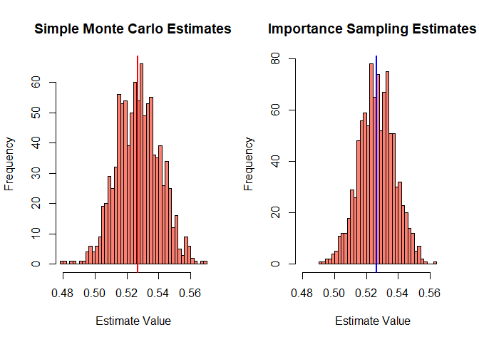

```r
# Plot the histograms
x.limits <- range(c(is.results, smc.results))

par(mfrow=c(1,2))

hist(smc.results, breaks=40, main="Simple Monte Carlo Estimates",
     xlab="Estimate Value", xlim=x.limits, col="salmon")
abline(v=mean.smc, col="red", lwd=2)

hist(is.results, breaks=40, main="Importance Sampling Estimates",
     xlab="Estimate Value", xlim=x.limits, col="salmon")
abline(v=mean.is, col="blue", lwd=2)
```

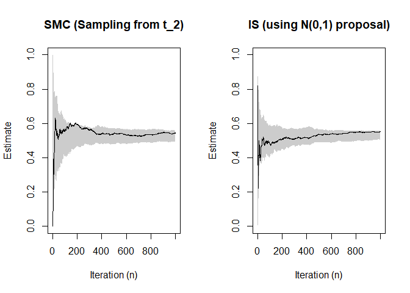

```r
# Set Parameters
N_max <- 1000
R <- 100

# Create Matrices to Store Results
smc_runs_matrix <- matrix(nrow = R, ncol = N_max)
is_runs_matrix <- matrix(nrow = R, ncol = N_max)

# Run Replications
for (i in 1:R) {
  # SMC Run
  t.f <- rt(N_max, df = 2)
  phi_vals_smc <- phi(t.f)
  smc_runs_matrix[i, ] <- cumsum(phi_vals_smc) / (1:N_max)

  # IS Run
  t.g <- rnorm(N_max)
  W <- dt(t.g, df = 2) / dnorm(t.g)
  phi_vals_is <- phi(t.g) * W
  is_runs_matrix[i, ] <- cumsum(phi_vals_is) / (1:N_max)
}

# Calculate Plotting Bands
smc_mean_line <- smc_runs_matrix[1, ]
smc_min_band <- apply(smc_runs_matrix, 2, min, na.rm=TRUE)
smc_max_band <- apply(smc_runs_matrix, 2, max, na.rm=TRUE)

is_mean_line <- is_runs_matrix[1, ]
is_min_band <- apply(is_runs_matrix, 2, min, na.rm=TRUE)
is_max_band <- apply(is_runs_matrix, 2, max, na.rm=TRUE)

iterations <- 1:N_max

# Plotting
par(mfrow = c(1, 2))

# Plot 1: SMC
smc_ylim <- range(c(smc_min_band, smc_max_band), na.rm = TRUE, finite = TRUE)
plot(iterations, smc_mean_line, type = "n", ylim = smc_ylim,
     main = "SMC (Sampling from t_2)", xlab = "Iteration (n)", ylab = "Estimate")
polygon(c(iterations, rev(iterations)), c(smc_min_band, rev(smc_max_band)),
        col = "grey80", border = NA)
lines(iterations, smc_mean_line, col = "black", lwd = 1)

# Plot 2: IS
is_ylim_clipped <- range(c(quantile(is_min_band, 0.05, na.rm = TRUE),
                           quantile(is_max_band, 0.95, na.rm = TRUE),
                           smc_ylim), na.rm=TRUE, finite=TRUE)
plot(iterations, is_mean_line, type = "n", ylim = is_ylim_clipped,
     main = "IS (using N(0,1) proposal)", xlab = "Iteration (n)", ylab = "Estimate")
polygon(c(iterations, rev(iterations)), c(is_min_band, rev(is_max_band)),
        col = "grey80", border = NA)
lines(iterations, is_mean_line, col = "black", lwd = 1)
```

Here the importance sampler (IS) estimator is actually performing better than the simple Monte Carlo (SMC) estimator with respect to variance which is initially unexpected. However, the choice of $\varphi$ above is crucial because this function has extremely light tails and decays to 0 faster than the standard normal density. This means that $\varphi$ dominates the integrand, forcing the integral to converge to a small, finite value. This effectively down-weights the problematic tail regions which tames the exploding weights. This means that choosing a poor proposal can be compensated by a clever choice of $\varphi$.

If $\varphi(t) = \exp{(|t|^{1/4})}$ then we completely change how the variance of the IS estimator behaves. The new function of $\varphi$ grows slowly as $|t|$ increases and unlike in part (c), does not decay faster than the standard normal density. This means we will not be able to control the importance weights when we sample from the tails of $N(0,1)$ causing them to explode. This will then lead to an IS estimator with infinite variance making it a useless estimator. Whereas, the SMC estimator would remain stable and well-behaved as the integral defining the variance would still be finite. Therefore, the SMC method would be the only reliable approach for this new function.